# Discounting

### Triangles in insurance

1. How long does it take to fully pay the claims?
2. How fast are they paid?
3. Is the initial estimate of the future conservative or optimistic?

There are far more questions and answers available, and there are many methods that can do the job. But for now, let’s understand at least the basics.

### What is a triangle

As losses take sometimes a number of years to be reported and then some more years to be paid, it is very hard to say at the end of the year whether we have “saved” enough money. For this reason, it makes sense to keep history of all claims related to 1 period.

Imagine this simple situation that shows a history of a single policy:

1. 1st December 2016 - insurance contract was signed to protect against car crash injury
2. 20th November 2017 - there was an accident. The person goes to hospital and does not care about calling insurance company
3. 1st January 2018 - person is finally home, but he will not be able to work for unknown time
4. 5th January 2018 - claim is reported. Doctors say, the person may require anoteher surgery in 6 months
5. 1st February 2018 - new symptoms are found (they seem to be coming from the accident) …
6. a few years later - the person finally starts working, but is partially disabled

#### Think about which year each information relates to (Exercise 0)

*Write down into your notes, what you think… In which year(s) of data can we find the above situation. Then let’s discuss.*

It makes sense to keep a chronological history of how much was paid for each of the items above. If you have many policies and not just the one as above, it makes sense to group them together and form a chronological payment history for every year. This is then usually displayed as a “triangle”, where the rows represent the years of origin (policy, accident, reporting date) and the columns represent how long it took until the information was recognized.

### What do we do with this?

Well, we want to take the advantage of the history that we have collected and predict what is likely to happen with the latest year, that we have just got to know about. It is basically a variation of the Linear Regression, where you learn from past patterns and apply them to predict future. To get what we are talking about, it is worth visualising this a bit. Use the ChainLadder package and explore the visaualize the triangle object from example there.

Load all necessary packages for the lesson

```r
library(dplyr)
library(ggplot2)
library(ChainLadder)
```

Load data about KPIs

```r
dt_KPI <- read.csv("./Data/lesson2_KPI.csv")
```

[output not shown]

#### Exercise 1

*As we will be working with ChainLadder library, explore it a little bit.* To understand what it is doing run the example below (demo from ChainLadder library)

```r
GenIns
```

```
      dev
origin      1       2       3       4       5       6       7       8       9
    1  357848 1124788 1735330 2218270 2745596 3319994 3466336 3606286 3833515
    2  352118 1236139 2170033 3353322 3799067 4120063 4647867 4914039 5339085
    3  290507 1292306 2218525 3235179 3985995 4132918 4628910 4909315      NA
    4  310608 1418858 2195047 3757447 4029929 4381982 4588268      NA      NA
    5  443160 1136350 2128333 2897821 3402672 3873311      NA      NA      NA
    6  396132 1333217 2180715 2985752 3691712      NA      NA      NA      NA
    7  440832 1288463 2419861 3483130      NA      NA      NA      NA      NA
    8  359480 1421128 2864498      NA      NA      NA      NA      NA      NA
    9  376686 1363294      NA      NA      NA      NA      NA      NA      NA
    10 344014      NA      NA      NA      NA      NA      NA      NA      NA
      dev
origin      10
    1  3901463
    2       NA
    3       NA
    4       NA
    5       NA
    6       NA
    7       NA
    8       NA
    9       NA
    10      NA
```

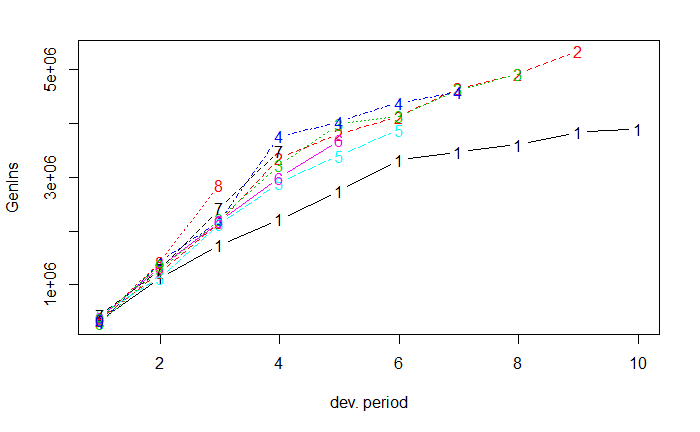

```r
plot(GenIns)
```

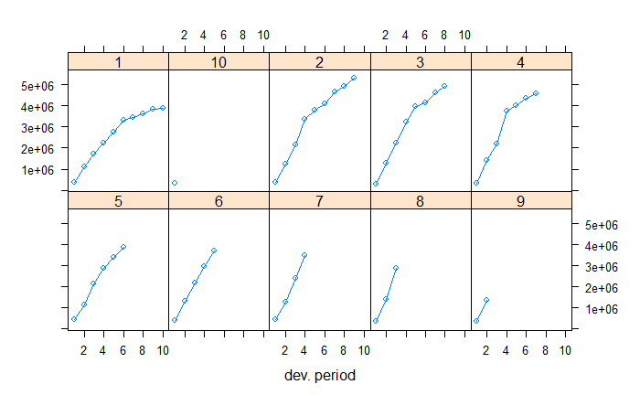

```r
plot(GenIns, lattice=TRUE)
```

*Think about some math, that could project the future for the “unfinished lines” (e.g. liner models?)* To explore a bit of math, look at the exmaples from help section on “chainladder” function

```r
?chainladder
```

The thing that is actually predicting the future is the age-to-age factors. Can you find them in the chainladder object?

*Now try to predict what happens with the linse using the chain ladder technique (hint: search for predict)*

Your solution

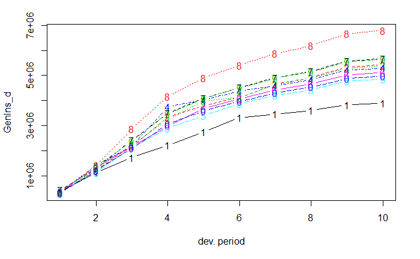

At the end this is all about age-to-age factors. There are many methods that calculate them, but at the end once you get them you know, how much more the claim will be in x years.

#### Exercise 2

Now let’s have a look at a couple of different triangles. The data is provided for 2 different businesses. It also shows 2 different claim types for each. Can you describe how different they are? Hint: Consider the length of tail, volatility, average sizes… Hint2: There are 2 types of data - paid and case. Start using Paid…

*YOUR SOLUTION* understand the data => run some simple overviews

```r
summary(dt_PaidCase)
```

```
      Business   ClaimSize   dataset_type       ay             dy
 3rd Party:208   Large:208   CASE:208     Min.   :2007   Min.   : 1.000
 House    :208   Small:208   PAID:208     1st Qu.:2008   1st Qu.: 2.000
                                          Median :2010   Median : 4.000
                                          Mean   :2010   Mean   : 4.154
                                          3rd Qu.:2012   3rd Qu.: 6.000
                                          Max.   :2016   Max.   :10.000
  SumOfamount
 Min.   :  -16579
 1st Qu.: 4061799
 Median : 9762547
 Mean   :12767683
 3rd Qu.:15751275
 Max.   :66489399
```

create a variable => filter data and covert to triangle. then convert to cummulative to use chainladder

*STEP 1: Take paid data for House business and Small claim size*

| Business | ClaimSize | dataset_type | ay | dy | SumOfamount |
| --- | --- | --- | --- | --- | --- |
| House | Small | PAID | 2007 | 3 | 14264692 |
| House | Small | PAID | 2007 | 4 | 14901055 |
| House | Small | PAID | 2007 | 5 | 15565689 |
| House | Small | PAID | 2007 | 6 | 15652035 |
| House | Small | PAID | 2007 | 7 | 15663740 |
| House | Small | PAID | 2007 | 8 | 15675924 |
| House | Small | PAID | 2007 | 9 | 15873957 |
| House | Small | PAID | 2007 | 10 | 15847900 |
| House | Small | PAID | 2008 | 2 | 12888649 |
| House | Small | PAID | 2008 | 3 | 15959212 |

[output cut: 42 more lines]

*STEP 2: Now convert the standard table into a triangle* Hint: %>% as.triangle(…)

```r
Paid_HH_sml <- Paid_HH_sml %>%
  as.triangle(origin="ay", dev="dy", value="SumOfamount")
```

*STEP 3: Now start plotting things to see more information*

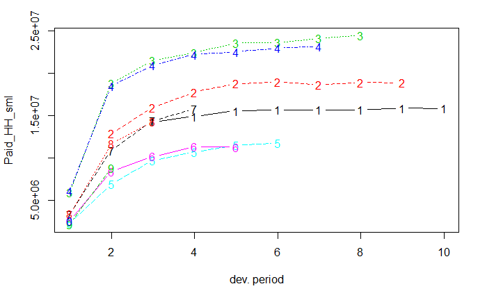

```r
plot(Paid_HH_sml)
```

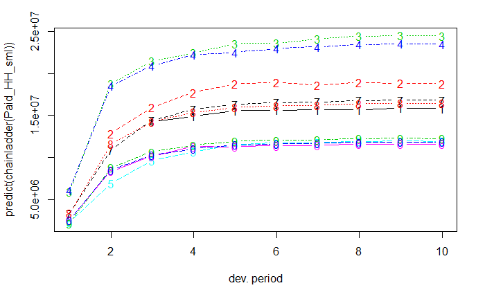

```r
plot(predict(chainladder(Paid_HH_sml)))
```

*STEP 4: And get the aging factors and some other stat’s out to see more details* Hint: ata(…)

```r
ata(Paid_HH_sml)
```

```
      dy
ay       1-2   2-3   3-4   4-5   5-6   6-7   7-8   8-9  9-10
  2007    NA    NA 1.045 1.045 1.006 1.001 1.001 1.013 0.998
  2008    NA 1.238 1.113 1.058 1.010 0.982 1.016 0.996    NA
  2009 3.196 1.142 1.045 1.049 1.004 1.021 1.013    NA    NA
  2010 3.052 1.132 1.060 1.014 1.020 1.010    NA    NA    NA
  2011 3.052 1.405 1.107 1.078 1.017    NA    NA    NA    NA
  2012 3.314 1.214 1.113 0.997    NA    NA    NA    NA    NA
  2013 3.314 1.324 1.093    NA    NA    NA    NA    NA    NA
  2014 3.495 1.229    NA    NA    NA    NA    NA    NA    NA
  2015 4.154    NA    NA    NA    NA    NA    NA    NA    NA
  smpl 3.368 1.241 1.082 1.040 1.011 1.003 1.010 1.004 0.998
  vwtd 3.295 1.215 1.077 1.039 1.011 1.005 1.011 1.003 0.998
```

*Now repeat for all types of buiness and sizes of claims. Compare the findings…*

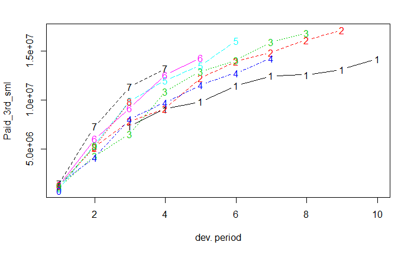

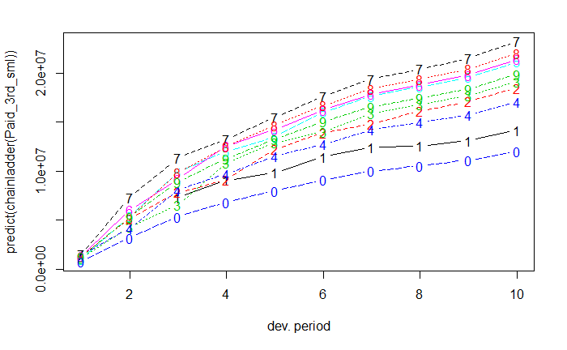

```r
#paid data, 3rd party business, small claim size
Paid_3rd_sml <- dt_PaidCase %>%
  filter(Business == "3rd Party" & ClaimSize == "Small" & dataset_type == "PAID")
Paid_3rd_sml <- Paid_3rd_sml %>% as.triangle(Paid_3rd_sml, origin = "ay", dev = "dy", value = "SumOfamount")
plot(Paid_3rd_sml)
plot(predict(chainladder(Paid_3rd_sml)))

ata(Paid_3rd_sml)
```

```
      dy
ay       1-2   2-3   3-4   4-5   5-6   6-7   7-8   8-9 9-10
  2007    NA    NA 1.242 1.081 1.167 1.087 1.008 1.044 1.08
  2008    NA 1.512 1.163 1.340 1.139 1.065 1.087 1.061   NA
  2009 3.757 1.526 1.653 1.187 1.088 1.134 1.057    NA   NA
  2010 2.886 1.935 1.207 1.184 1.104 1.116    NA    NA   NA
  2011 5.151 1.830 1.214 1.124 1.187    NA    NA    NA   NA
  2012 4.437 1.518 1.370 1.135    NA    NA    NA    NA   NA
  2013 4.838 1.548 1.169    NA    NA    NA    NA    NA   NA
  2014 3.969 1.895    NA    NA    NA    NA    NA    NA   NA
  2015 4.217    NA    NA    NA    NA    NA    NA    NA   NA
  smpl 4.179 1.681 1.288 1.175 1.137 1.100 1.051 1.052 1.08
  vwtd 4.156 1.667 1.273 1.171 1.137 1.101 1.053 1.053 1.08
```

*If you are now comforatble with what this does, try doing the same, but using additional information: The Case data!* Hint: Sum Paid and Case together to come up with the final claims estimates (the Incurred claims)

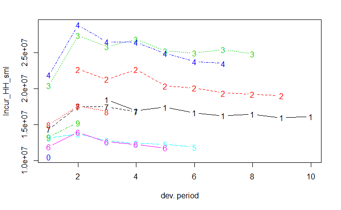

```r
#house business, small claim size, paid+case
Incur_HH_sml <- dt_PaidCase %>% filter(Business == "House" & ClaimSize == "Small")
Incur_HH_sml <- Incur_HH_sml %>% as.triangle(Incur_HH_sml, origin = "ay", dev = "dy", value = "SumOfamount")
plot(Incur_HH_sml)
```

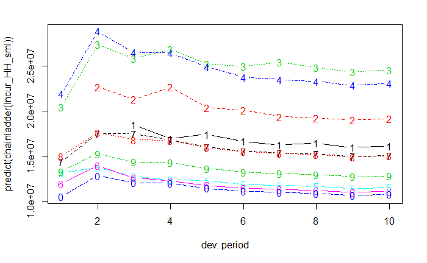

```r
plot(predict(chainladder(Incur_HH_sml)))
```

```r
ata(Incur_HH_sml)
```

```
      dy
ay       1-2   2-3   3-4   4-5   5-6   6-7   7-8   8-9  9-10
  2007    NA    NA 0.917 1.028 0.955 0.974 1.014 0.970 1.009
  2008    NA 0.939 1.065 0.899 0.985 0.965 0.990 0.990    NA
  2009 1.343 0.942 1.040 0.940 0.989 1.018 0.976    NA    NA
  2010 1.319 0.918 0.998 0.941 0.954 0.989    NA    NA    NA
  2011 1.041 0.931 0.970 0.991 0.967    NA    NA    NA    NA
  2012 1.169 0.904 0.975 0.958    NA    NA    NA    NA    NA
  2013 1.218 1.000 0.961    NA    NA    NA    NA    NA    NA
  2014 1.174 0.955    NA    NA    NA    NA    NA    NA    NA
  2015 1.148    NA    NA    NA    NA    NA    NA    NA    NA
  smpl 1.202 0.941 0.989 0.960 0.970 0.987 0.993 0.980 1.009
  vwtd 1.220 0.941 0.996 0.952 0.971 0.989 0.991 0.981 1.009
```

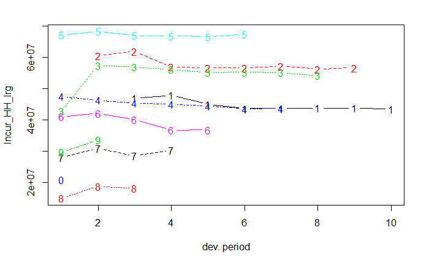

```r
#house business, large claim size, paid+case
Incur_HH_lrg <- dt_PaidCase %>% filter(Business == "House" & ClaimSize == "Large")
Incur_HH_lrg <- Incur_HH_lrg %>% as.triangle(Incur_HH_lrg, origin = "ay", dev = "dy", value = "SumOfamount")
plot(Incur_HH_lrg)
```

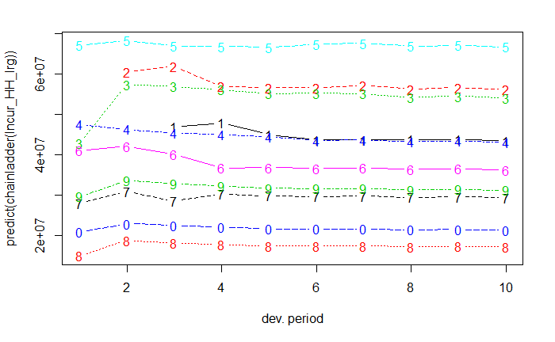

```r
plot(predict(chainladder(Incur_HH_lrg)))
```

```r
ata(Incur_HH_lrg)
```

```
      dy
ay       1-2   2-3   3-4   4-5   5-6   6-7   7-8   8-9  9-10
  2007    NA    NA 1.021 0.938 0.972 1.000 1.001 1.000 0.993
  2008    NA 1.023 0.919 0.996 1.000 1.008 0.985 1.006    NA
  2009 1.340 0.991 0.986 0.983 1.001 0.998 0.984    NA    NA
  2010 0.974 0.979 0.991 0.990 0.979 1.004    NA    NA    NA
  2011 1.018 0.980 0.998 0.996 1.014    NA    NA    NA    NA
  2012 1.024 0.954 0.914 1.003    NA    NA    NA    NA    NA
  2013 1.104 0.923 1.061    NA    NA    NA    NA    NA    NA
  2014 1.252 0.966    NA    NA    NA    NA    NA    NA    NA
  2015 1.133    NA    NA    NA    NA    NA    NA    NA    NA
  smpl 1.121 0.974 0.984 0.984 0.993 1.002 0.990 1.003 0.993
  vwtd 1.096 0.980 0.980 0.984 0.995 1.003 0.990 1.004 0.993
```

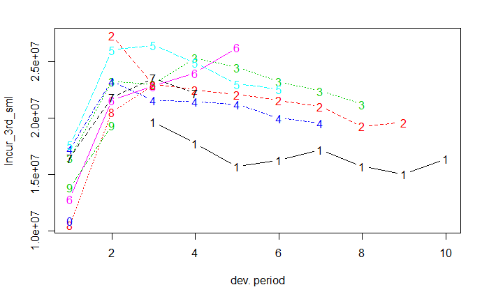

```r
#3rd party business, small claim size, paid+case
Incur_3rd_sml <- dt_PaidCase %>% filter(Business == "3rd Party" & ClaimSize == "Small")
Incur_3rd_sml <- Incur_3rd_sml %>% as.triangle(Incur_3rd_sml, origin = "ay", dev = "dy", value = "SumOfamount")
plot(Incur_3rd_sml)
```

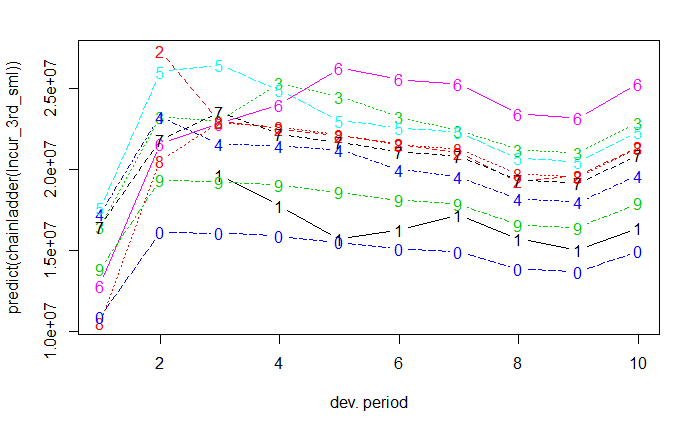

```r
plot(predict(chainladder(Incur_3rd_sml)))
```

```r
ata(Incur_3rd_sml)
```

```
      dy
ay       1-2   2-3   3-4   4-5   5-6   6-7   7-8   8-9  9-10
  2007    NA    NA 0.904 0.884 1.036 1.054 0.917 0.954 1.091
  2008    NA 0.841 0.980 0.982 0.977 0.974 0.916 1.018    NA
  2009 1.413 0.988 1.102 0.966 0.950 0.962 0.949    NA    NA
  2010 1.349 0.926 0.995 0.989 0.942 0.979    NA    NA    NA
  2011 1.477 1.016 0.941 0.924 0.981    NA    NA    NA    NA
  2012 1.683 1.059 1.051 1.094    NA    NA    NA    NA    NA
  2013 1.324 1.079 0.943    NA    NA    NA    NA    NA    NA
  2014 1.957 1.115    NA    NA    NA    NA    NA    NA    NA
  2015 1.396    NA    NA    NA    NA    NA    NA    NA    NA
  smpl 1.514 1.003 0.988 0.973 0.977 0.992 0.927 0.986 1.091
  vwtd 1.484 0.996 0.988 0.977 0.973 0.988 0.928 0.989 1.091
```

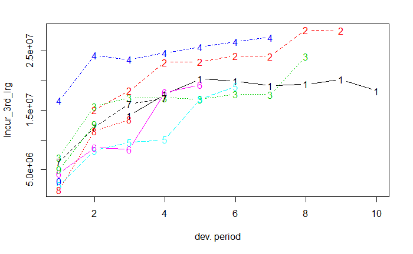

```r
#3rd party business, large claim size, paid+case
Incur_3rd_lrg <- dt_PaidCase %>% filter(Business == "3rd Party" & ClaimSize == "Large")
Incur_3rd_lrg <- Incur_3rd_lrg %>% as.triangle(Incur_3rd_lrg, origin = "ay", dev = "dy", value = "SumOfamount")
plot(Incur_3rd_lrg)
```

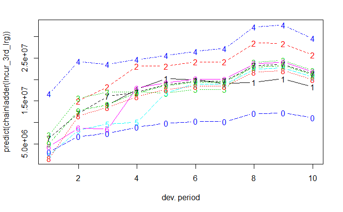

```r
plot(predict(chainladder(Incur_3rd_lrg)))
```

```r
ata(Incur_3rd_lrg)
```

```
      dy
ay       1-2   2-3   3-4   4-5   5-6   6-7   7-8   8-9  9-10
  2007    NA    NA 1.257 1.144 0.984 0.957 1.015 1.041 0.905
  2008    NA 1.217 1.263 1.001 1.042 0.999 1.182 0.997    NA
  2009 2.210 1.093 0.999 0.986 1.049 1.000 1.362    NA    NA
  2010 1.452 0.971 1.048 1.040 1.035 1.027    NA    NA    NA
  2011 3.512 1.167 1.047 1.681 1.122    NA    NA    NA    NA
  2012 1.990 0.969 2.135 1.072    NA    NA    NA    NA    NA
  2013 1.911 1.326 1.062    NA    NA    NA    NA    NA    NA
  2014 7.300 1.166    NA    NA    NA    NA    NA    NA    NA
  2015 2.504    NA    NA    NA    NA    NA    NA    NA    NA
  smpl 2.983 1.130 1.259 1.154 1.047 0.996 1.186 1.019 0.905
  vwtd 2.143 1.115 1.192 1.104 1.043 0.998 1.182 1.015 0.905
```

```r
## 3rd Party & Small:
```

### Short or Long tail

In insurance this means how fast is the data fully developed. The age-to-age factors help you understand exactly this. What would the age-to-age factors look like to make the business short/long tail? Are the lines of business in the exercise above short or long tailed? Try to come up with the meant payment term (weighted average of the duration until the claim is paid)

So hopefully by this time you know how the losses were calculated for you to use in previous class…

```r
#House business - cca 4  roky trva, pokial sa losses zastabilizuju a dalej sa radikalne nemenia. Pri 3rd party to trva dlhsie.

#Pri House business - ak sa nieco stane, tak sa to zaplati a predpoklada sa, ze s tym nebudu spojene dalsie vyznamne naklady (preto sa naklady "zastabiluzuju"). Pri 3rd party business moze nahrada skody trvat nepomerne dlhsie.
```

#### Exercise 3

There are a couple of different types of business in the data from previous lesson. What do you think, how long are the average delays in payments? Set up a table, that will *show your assumptions and commit it to your git repository.*

```r
summary(dt_KPI)
```

```
      Region         Unit      Segment           Business        Year
         :215          :215        :215              :215   Min.   :2012
 Alandia :339   Unit8  :128   Big  :529   Housing    : 97   1st Qu.:2013
 Belandia:213   Unit2  :119   Small:357   Travel     : 97   Median :2014
 Cergo   :334   Unit4  :117               Third Party: 96   Mean   :2014
                Unit6  :117               Packaging  : 95   3rd Qu.:2015
                Unit7  :116               (Other)    :310   Max.   :2016
                (Other):289               NA's       :191   NA's   :215
     Losses             Expenses            Premium             UWR.Plan.
 Min.   : -9092656   Min.   :-72120148   Min.   :  -3631017   Min.   :-54316456
 1st Qu.:        0   1st Qu.:        0   1st Qu.:         0   1st Qu.:        0
 Median :   900380   Median :  4787344   Median :  12745263   Median :    41852
 Mean   : 37749573   Mean   : 41341279   Mean   : 120686400   Mean   :  2693978
 3rd Qu.: 28659645   3rd Qu.: 35100835   3rd Qu.: 108273340   3rd Qu.:  1816444
 Max.   :714254063   Max.   :934250718   Max.   :2273357874   Max.   :139925504
 NA's   :215         NA's   :215         NA's   :215          NA's   :215
```

### Discounting losses

It is very unlikely, that we incur the whole loss on the *very first day*. This allows the insurance company to *invest* the premium received and earn som interest on it. So one way of thinking about our previous example would be to think about *the future value of money* collected at the time of the claim. In reality we need to know the answers now, so *discounting the losses* is more practical then earning interest on expenses.

Let’s check the data now. Were your expectations above supported by the calculation? Add comments to your notes if needed…

#### Exercise 4

Use the data provided in exercise 2 and try to come up with an estimates of the average duration. How does it work? Well, discounting apart, in what year does the average payment happen? HINT: (Here you definitely use paid claims, and it is enough to calculate weighted average of incremental payment)

*STEP 1: get the weights of incremental paid triangle => this is what we are intrested in because individual payments matter*

*STEP 2: average duration (calculate a weighted sum, where the weight is the number of year/total cummulative paid sum)*

*Does the value calculated correspond to your assumed value for the given business in Exercise 2? Comment on the findings in your notes…*

Now let’s try to be more exact. What do we need to calculate this? Of course the interest rates, but let’s park that for now and use just [risk free rates](https://en.wikipedia.org/wiki/Risk-free_interest_rate).

So what is the other most important factor?

Usually we would use a formula like this one: `Loss_y = Loss_x * (1 + interest)^(y-x)`

The durations until payments `(y-x)` is a generic answer. Information about the claims history and the payments will help us derive it. We can start at simple averaging (as in the previous exercise) and saying that is the duration discounting for the period equal to aveage duration. But we can be more precise in weighting and use the age-to-age factors more precisely. So let’s try that… This detailed approach is usually used with the Swap rates for individual durations. You can try that at home…

#### Exercise 5

Now, assume an interest rate of 5%. How will the discounting change this? *Calculate a factor to be applied to the final incurred claims, to make discout it to present value.*

Let’s start simply: What would the average disocunt factor be? Use the average duration from Exercise 4

Recall what is UWR from Lesson 2. Assume premium and expenses are calculated on day 1. *Can you calculate a sigle number, that could be used to discount the claims to arrive to Net present value of UWR?*

#### Exercise 6

Now, let’s have a look at it from the other way around. The following dataset includes the same data you were analysing in class 2, but it is all discounted…

```r
NPV_data <- read.csv("./Data/lesson4_NPV.csv")
```

*What is the average duration in all of these cases assuming a discount rate of 5%?*

*What is the worst performing portfolio now?* (Hint: Create additional shiny graphs, but using the discounted values)

### Capital requirements

To make it even more real, we need to take into account another perspective as well. This is the amount of money we need to hold to be able to pay the claims right when they appear. In here the *claims volatility* kicks in.

Imagine you are starting insuring against flood.

The floods usually happen once every 100 years and when it happens, it destroys your house significantly.

You have collected some reasonable premium, that is probably less then the value of the loss you can expect (no one would pay the same amount of money that the repair will cost to the insurance company, as they would rather save it in a bank). The next year, the flood comes… and so the insurance company must pay… *But do they have enough money?* How much money would you expect them to have? (reflect in your notes sections)

#### Exercise 7

Imagine there are 100 houses around a river and each is worth 100,000. A big flood happens once every 100 and destroys everything. A small one every 5 years and destroys 1 house. *What is the average loss per year (simple premium)? What is the volatility of the losses?*

*How much do you think a reasonable premium should be to protect the customers?*

### Risk based capital

Insurance industry is very regulated. One of the main reason is the situation above. No government wants it’s people to be unprotected or unpaid if a claim happens. That means, an insurance company must have some extra money on top of the expected claim payments to allow for the event to happen at different times then just average occurances (once every 100 year like in example above).

What is driving the capital requirement?

#### Exercise 8

*Think about why a portfolio may need more (or less) capital to be allowed to insure business. Write down your ideas into your notes.*

Obviously, the bigger the size, the more capital is needed. But this still does not meant something is more or less risky. It is much better to weight the requirement by size. For this reason we use `Capital_Intensity_Ratio(CIR) = Required_Capital / Net_Earned_Premium(NEP)`.

#### Exercise 9

Use the following data [CIR] to try to come up with some examples that support your ideas from your reflection in previous exercise. *Look at the data provided. Identify examples, where 2 portfolios are similar (1 dimension is different), and the CIR is bigger or smaller. Be creative and find any dependencies…*

```r
CIR_data <- read.csv("./Data/lesson4_CIR.csv")
```

What is the total value of capital required to run the whole business from lesson 2? Use the data provided that refers to the same portfolios, you were looking at in lesson2. How has it changed over the years?

### Cost of capital

As in the example above, there is no way for a starting insurance company to collect enough money up front. They are borrowed from shareholders or banks. These require interest in excess of risk free rate. You can try to find out a reasonable risk margin for insurance companies in google (depending on their rating and risk profile). Let’s assume, we need to return additiona 10% on top of the money that we borrow. Let’s also assume we have no free capital now and we have to borrow everything.

How does this additional challenge change the porfitabilty of the buiness?

#### Exercise 10 => Homeworks (group everything together)

*Using the same data we have discounted, try to allow for additional 10% (on top of risk free rate) of the capital needed for that portfolio.* What is the Economic profit before tax (NPV UWR - Capital costs) for each portfolio? Which one of them is the most profitable? Is the worst one from previous investigation still the worst?

STEPS: You know what the Mean term is of the data (also part of CIR_data as the last column), as you know what the discount factors are and you assumed 5% discount rate (Exercies 6) - chose whichevery you find more reasonable. You also know what the capital intensity ratios are (Exercise 9). You also know the Net Earned Premium from earlier lessons (dt_KPI) How much does it cost to hold the Capital amount in terms of interest paid for that for the average (Mean Term) period? Now you can combine everything and calculate teh Economic Profit :) Hint1: Using ‘dplyr’ package and function left_join requires column names to be the same to join…

### Latest view of the loss development - EXTRA

Ok, so now you should know something about triangles and discounting and capital and how it all links together. There is another use of the triangles though and the very last adjustment to our profitability. As the external capital is usually quite expensive, insurers need to sometimes strengthen the reserves to have more money saved for adverse claims (like the flood in the capital section). There are also claims, that have happened and we are not aware of yet, which is another reason for having extra money saved. Over the years, the reserves are released, as claims are paid and the money is not needed. So can we somehow project what the future losses will be after all reserve releases? There is an additional dataset provided, that shows historical view of the losses for a given year, and it is updated year on year.

#### BONUS HOMEWORK CANDIDATE - EXTRA BONUS

Use this final triangle to come up with your view on what the ultimate loss for 2016 will look like for every portfolio. Calculate the extra money, that will be released in a couple of years. Present the latest view NPV UWR for all portfolios and show that as a diagnostic in your dashboard from lesson 2.